# Predicting quality of weight lifting exercises using data from wearable devices

Irena Papst

2019-08-13

## Background and motivation

Wearable activity monitors have become quite popular and increasingly inexpensive, enabling individuals to automatically track many features of the physical activity they perform each day: from type of exercise to duration to frequency. While a sufficient quantity of regular exercise is important for improving and maintaining good health, the *quality* of exercise performed is also consequential. This feature is difficult to track directly, but it may perhaps be inferred from data gathered using wearable devices.

The goal of this project is to use data collected from sensors worn by a person to predict the quality of a weight-lifting exercise performed.

## Data

We use data from the Weight Lifting Exercises Dataset (Velloso et al. 2013). Six young and healthy participants were asked to perform one set of 10 repetitions of the unilateral dumbbell bicep curl perfectly (class A), or with one of four mistakes: throwing elbows to the front (class B), lifting or lowering the dumbbell only halfway (classes C and D, respectively), and throwing the hips to the front (class E). While the participants had little weight lifting experience, they were supervised by an experienced weight lifter to ensure the exercises were completed in the manner specified, and they used a relatively light dumbbell (1.25 kg) to be able to focus on properly executing the required motions.

Four orientation sensors tracked the exercises and were located on the dumbbell, as well as on the participant’s upper arm, forearm, and belt. These sensors record roll, pitch, yaw, total acceleration (four measurements per sensor for a total of 16 measurements), as well as gyroscope, accelerometer, and magnetoscope readings for each of the $x$, $y$, and $z$ coordinates (three measurements per coordinate per sensor for a total of 36 measurements). As a result, we have a maximum of 52 measurements upon which we can base our prediction model.

```r
## Load data
training <- read_csv("data/pml-training.csv")
testing <- read_csv("data/pml-testing.csv")
```

```r
## Tidy data

## Training data
training <- training %>%
  ## Filter training to remove rows with summary stats
  ## (none to predict in the test set so probably not relevant)
  filter(new_window == "no") %>%
  ## Remove cols where all vals are NA
  map(~.x) %>%
  discard(~all(is.na(.x))) %>%
  map_df(~.x) %>%
  ## Remove cols irrelevant to prediction
  select(-c(X1, user_name,
            raw_timestamp_part_1, raw_timestamp_part_2,
            cvtd_timestamp,
            new_window, num_window))

## Testing data
testing <- testing %>%
    ## Remove cols where all vals are NA
  map(~.x) %>%
  discard(~all(is.na(.x))) %>%
  map_df(~.x) %>%
  ## Remove cols irrelevant to prediction
  select(-c(X1, user_name,
            raw_timestamp_part_1, raw_timestamp_part_2,
            cvtd_timestamp,
            new_window, num_window))
```

## Model

We are trying to predict a categorical outcome with more than two values using continuous predictors, so linear or logistic regression are inappropriate. Naive Bayes requires the assumption that the data follows a probabilistic model, but we have no reason to assume particular distributions for our predictors. Instead, we choose a random forest as it is compatible with our input data and can be very accurate. It is true that random forests can be slow and hard to interpret, but these are not major concerns here, as we seek to run this experiment only once and are primarily interested in accuracy and not model interpretability.

### Feature selection

Another issue with random forests is the potential for overfitting, so we start by looking at model accuracy as a function of the number of predictors to decide on the number of predictors in our final model.

```r
## Set seed for reproducibility
set.seed(1346)

## Change training tibble to dataframe for compatibility with rfcv()
training <- as.data.frame(training)
training$classe <- as.factor(training$classe)
cross_val <- rfcv(trainx = select(training, -classe),
                  trainy = training$classe)
```

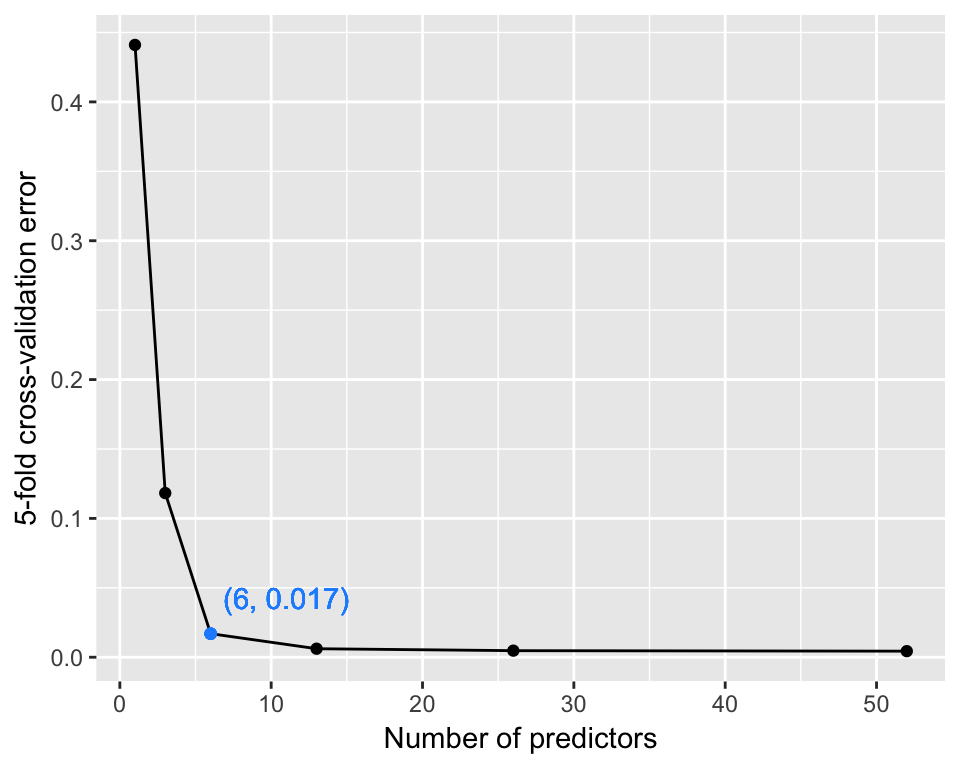

**Figure 1: The effect of the number of predictors on model accuracy.** The out-of-bag error is estimated using 5-fold cross-validation and the $n$ most important predictors (based on mean difference in accuracy of results) at each point. The model is still highly accurate at only six predictors.

```r
## Plot estimated OOS error from cross-validation as a function of the number of predictors
cv_error <- data.frame(n_var = cross_val$n.var,
                       error = as.numeric(cross_val$error.cv))
p <- ggplot(cv_error, aes(x = n_var, y = error)) +
  geom_line() +
  geom_point() +
  geom_point(aes(x = 6, y = error[4]), colour = "dodgerblue") +
  geom_text(aes(x = 6+5, y = error[4]*2.5,
                label = paste0("(6, ", round(error[4], 3), ")")),
            colour = "dodgerblue") +
  xlab("Number of predictors") +
  ylab("5-fold cross-validation error")
print(p)
```

Remarkably, even with just 6 variables out of a possible 52, the model still achieves a $1.7 \%$ error rate, for an accuracy of $98.3 \%$.

Next, we train another random forest model on all 52 predictors, so that we may find the six most important ones for our final model. We use the default values in the `randomForest()` function, keeping track of the importance of each predictor for correctly classifying each outcome type.

```r
full_model <- randomForest(classe ~ ., data = training,
                           importance = TRUE)
```

Since we are most interested in accuracy, we sort the list of predictors by mean decrease in accuracy (after permuting predictors, averaged over all trees) recorded during model training and choose the six most important predictors (where a larger number indicates more importance in the model):

```r
six_preds <- names(sort(importance(full_model)[,6], decreasing = TRUE))[1:6]
print(six_preds)
```

```
## [1] "yaw_belt"          "roll_belt"         "pitch_belt"
## [4] "magnet_dumbbell_z" "magnet_dumbbell_y" "pitch_forearm"
```

## Results

### Estimating out-of-bag error

We train a random forest model with these six predictors, keeping all other options at their default values.

```r
preds <- paste(six_preds, collapse = " + ")
form <- paste0("classe ~ ", preds)
six_model <- randomForest(as.formula(form), data = training)
print(six_model)
```

```
##
## Call:
##  randomForest(formula = as.formula(form), data = training)
##                Type of random forest: classification
##                      Number of trees: 500
## No. of variables tried at each split: 2
##
##         OOB estimate of  error rate: 1.45%
## Confusion matrix:
##      A    B    C    D    E class.error
## A 5415   14   26   12    4  0.01023579
## B   30 3623   50   13    2  0.02555137
## C    9   17 3304   22    0  0.01431981
## D    5    2   29 3107    4  0.01271052
## E    1   24    8    6 3489  0.01105442
```

For the six predictor model, the out-of-bag (OOB) estimate of the error rate is $1.45$%, indicating that our model is already very accurate, and only requires the readings from three sensors: belt, dumbbell, forearm. However, of our six most important predictors, the three most important all come from one sensor: the belt sensor. It would be interesting to see whether we can get similar accuracy for a model that relies only on the belt sensor (namely the roll, pitch, and yaw measurements), reducing the number of sensors required for very accurate prediction from three to one, which would be more economically viable for a wearable fitness tracker product.

```r
three_preds <- six_preds[1:3]
preds <- paste(three_preds, collapse = " + ")
form <- paste0("classe ~ ", preds)
three_model <- randomForest(as.formula(form), data = training)
print(three_model)
```

```
##
## Call:
##  randomForest(formula = as.formula(form), data = training)
##                Type of random forest: classification
##                      Number of trees: 500
## No. of variables tried at each split: 1
##
##         OOB estimate of  error rate: 13.32%
## Confusion matrix:
##      A    B    C    D    E class.error
## A 4972  116  194  167   22  0.09120819
## B  248 3126  250   60   34  0.15922539
## C  344  225 2544  194   45  0.24105012
## D  205   38   78 2755   71  0.12456308
## E  109   46   66   47 3260  0.07596372
```

Alas, relying on only these three belt sensor measurements gives an OOB estimate for the error rate of $13.32$%, which is an order of magnitude worse than the six predictor model. Of course, this result is not all that surprising given that our earlier 5-fold cross-validation experiment predicted an OOB error rate of $11.82$% for the three most important predictors (see Figure 1).

For our final model, we select the one with the six most important predictors: the belt yaw, roll, and pitch, the $y-$ and $z-$coordinates of the dumbbell magnetoscope, and the forearm pitch.

### Predict

We now predict on 20 held-out test cases that have not been used in any way to train our model.

```r
predict_test <- predict(six_model, newdata = testing)
print(predict_test)
```

```
##  1  2  3  4  5  6  7  8  9 10 11 12 13 14 15 16 17 18 19 20
##  B  A  B  A  A  E  D  B  A  A  B  C  B  A  E  E  A  B  B  B
## Levels: A B C D E
```

## References

Velloso, Eduardo, Andreas Bulling, Hans Gellersen, Wallace Ugulino, and Hugo Fuks. 2013. “Qualitative Activity Recognition of Weight Lifting Exercises.” In *Proceedings of the 4th Augmented Human International Conference*, 116–23. ACM.